# Assignment - Lecture 06

Ann-Sophie Frind

2024-04-16

# Preparations

```r
suppressPackageStartupMessages({
  library(AnnotationHub)
  library(ensembldb)
  library(GenomicRanges)
  library(ggplot2)
  # library(memes) # for the meme-based methods -- COMMENT OUT when using alternatives
  library(motifmatchr) # for scanning sequences for matches of given motifs
  library(Biostrings) # for handling sequences
  library(MotifDb) # database of motifs
  library(TFBSTools) # for handling some motif formats
  library(universalmotif) # for converting motifs to various formats
  library(PWMEnrich) # for R-based motif enrichment analysis (position weight motive (see slides: graph with nucleotide letters))
})
```

```
## See system.file("LICENSE", package="MotifDb") for use restrictions.
```

# 1. Choose a transcription factor, e.g. CREB1, REST, GATA5, EGR1, GCR and download the peaks for that factor

- The genomes have to be the same. The first genome is the one the peaks were aligned to. The second one is the genome that we align the motifs to.
- Pay attention to the chromosome naming convention. ENCODE data uses the UCSC convention, which means that chromosome gets named “chr4”. The Ensembl convention instead calls it just “4”. So if we tried to overlap stuff between these two systems, we wouldn’t find anything. Fortunately, you can change the naming convention of most objects (e.g. GenomicRanges) in R, using for instance seqlevelsStyle(x) <- “ensembl” to force a GRanges (e.g. of your peaks) to use the ensembl convention.
- The peaks stem from human in vitro differentiated cells (hIVD)). Link: https://www.encodeproject.org/experiments/ENCSR000BTV/

```r
# Download
download.file("https://www.encodeproject.org/files/ENCFF138KSX/@@download/ENCFF138KSX.bed.gz", "hIVD_REST.bed.gz")

# Import the data in the right format
peaks <- rtracklayer::import("hIVD_REST.bed.gz", format="NarrowPeak")

# Change the convention of the chromosome names to ensembl (i.e. without 'chr')
seqlevelsStyle(peaks) <- "Ensembl" # to change the convention
REST_peaks_chr1 <- peaks[seqnames(peaks)=="1"]# less data
head(REST_peaks_chr1)
```

```
## GRanges object with 6 ranges and 6 metadata columns:
##       seqnames              ranges strand |        name     score signalValue
##          <Rle>           <IRanges>  <Rle> | <character> <numeric>   <numeric>
##   [1]        1   81023120-81023654      * |        <NA>      1000     480.714
##   [2]        1 164320758-164321201      * |        <NA>      1000     343.425
##   [3]        1   33409943-33410508      * |        <NA>      1000     331.609
##   [4]        1   74474522-74475022      * |        <NA>      1000     324.827
##   [5]        1   30276204-30276733      * |        <NA>      1000     318.537
##   [6]        1 192539736-192540145      * |        <NA>      1000     277.855
##          pValue    qValue      peak
##       <numeric> <numeric> <integer>
##   [1]        -1   3.89437       266
##   [2]        -1   3.89437       230
##   [3]        -1   3.89437       206
##   [4]        -1   3.89437       285
##   [5]        -1   3.89437       233
##   [6]        -1   3.89437       198
##   -------
##   seqinfo: 24 sequences from an unspecified genome; no seqlengths
```

```r
ah <- AnnotationHub()

q <- AnnotationHub::query(ah, c("TwoBit", "GRCh38")) # Here an error messages occurred: the function "query()" is used by different packages, so you have to specify the package (AnnotationHub).
q # I chose one of the the bottom ones = the newest (?)
```

```
## AnnotationHub with 120 records
## # snapshotDate(): 2023-10-23
## # $dataprovider: Ensembl
## # $species: Homo sapiens, homo sapiens
## # $rdataclass: TwoBitFile
## # additional mcols(): taxonomyid, genome, description,
## #   coordinate_1_based, maintainer, rdatadateadded, preparerclass, tags,
## #   rdatapath, sourceurl, sourcetype
## # retrieve records with, e.g., 'object[["AH49722"]]'
##
##              title
##   AH49722  | Homo_sapiens.GRCh38.cdna.all.2bit
##   AH49723  | Homo_sapiens.GRCh38.dna.primary_assembly.2bit
##   AH49724  | Homo_sapiens.GRCh38.dna_rm.primary_assembly.2bit
##   AH49725  | Homo_sapiens.GRCh38.dna_sm.primary_assembly.2bit
##   AH49726  | Homo_sapiens.GRCh38.ncrna.2bit
##   ...        ...
##   AH106282 | Homo_sapiens.GRCh38.cdna.all.2bit
##   AH106283 | Homo_sapiens.GRCh38.dna.primary_assembly.2bit
##   AH106284 | Homo_sapiens.GRCh38.dna_rm.primary_assembly.2bit
##   AH106285 | Homo_sapiens.GRCh38.dna_sm.primary_assembly.2bit
##   AH106286 | Homo_sapiens.GRCh38.ncrna.2bit
```

```r
genome <- ah[["AH106283"]]
```

```
## loading from cache
```

```
## require("rtracklayer")
```

```r
# we'll load it into memory:
genome_seqs <- import(genome)

# if your genome was a fasta file instead, import using Biostrings::readDNAStringSet()
```

# 2. Identify the instances of the factor’s motif

Often motifs indicate sequence-specific binding sites for proteins such as nucleases and transcription factors (TF).

```r
# we search for "REST" in the motif database
motifs <- query(MotifDb, "REST")
# there are several matching motifs:
names(motifs)
```

```
##  [1] "Hsapiens-HOCOMOCOv10-REST_HUMAN.H10MO.A"
##  [2] "Mmusculus-HOCOMOCOv10-REST_MOUSE.H10MO.A"
##  [3] "Hsapiens-HOCOMOCOv11-core-A-REST_HUMAN.H11MO.0.A"
##  [4] "NA-HOMER-REST-NRSF(Zf)/Jurkat-NRSF-ChIP-Seq/Homer"
##  [5] "Hsapiens-JASPAR_CORE-REST-MA0138.2"
##  [6] "Hsapiens-JASPAR_2014-REST-MA0138.2"
##  [7] "Hsapiens-jaspar2016-REST-MA0138.1"
##  [8] "Hsapiens-jaspar2016-REST-MA0138.2"
##  [9] "Hsapiens-jaspar2018-REST-MA0138.1"
## [10] "Hsapiens-jaspar2018-REST-MA0138.2"
## [11] "Hsapiens-jaspar2022-REST-MA0138.2"
## [12] "Hsapiens-SwissRegulon-REST.SwissRegulon"
## [13] "Mmusculus-UniPROBE-Irx3.UP00223"
## [14] "Mmusculus-UniPROBE-Irx3.UP00223.a272"
## [15] "Mmusculus-UniPROBE-Irx6.UP00150"
```

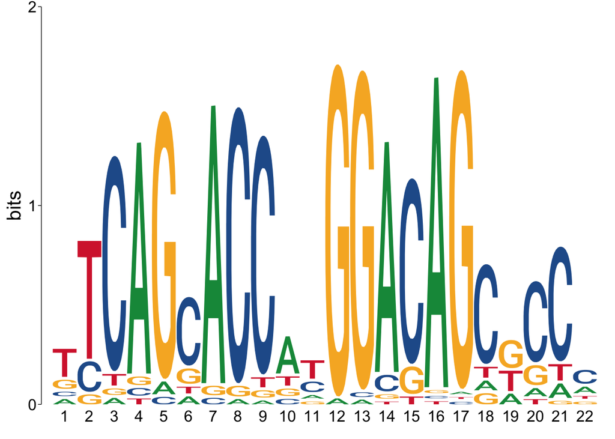

```r
# we select one:
REST_motif <- motifs[["Hsapiens-HOCOMOCOv10-REST_HUMAN.H10MO.A"]]
# we visualize it:
view_motifs(REST_motif)
```

# 3. Answer the following questions:

The matchMotifs() function takes motifs (motif2), genomic sequences (subject), and a reference genome (genome) as input and *returns the positions of the matched motifs within the genomic sequences*. This can be useful for identifying potential binding sites for transcription factors or other DNA-binding proteins within genomic regions of interest. **I also always got the error message in this chunk “Error in value[3L] : record 3 (1:204837492-204837830) was truncated file: genome.fa”, and therefore couldn’t get/check results**

```r
# if you don't already have the genome in fasta format saved somewhere, convert it to that format:
Biostrings::writeXStringSet(genome_seqs, "genome.fa")
# We also need to convert the motif to a format that this package (motifmatchr) will accept
motif2 <- convert_motifs(REST_motif, class="TFBSTools-PWMatrix")
moi <- motifmatchr::matchMotifs(motif2, subject=REST_peaks_chr1, genome=Rsamtools::FaFile("genome.fa"), out="positions")
# specify that we want the function to return the genomic position of each motif match
moi <- moi[[1]] # we scanned for just one motif, so we get the results for that motif
head(moi)
```

[output not shown]

## 3.1. Of all the peaks, what proportion contains a motif for the factor?

Expected form of an answer: of the XX peaks, XX (XX%) contain a motif

```r
peaks_with_motif <- overlapsAny(REST_peaks_chr1, moi)
proportion_with_motif <- sum(peaks_with_motif) / length(REST_peaks_chr1) * 100
print(paste("Of the", length(REST_peaks_chr1),"REST peaks,", sum(peaks_with_motif), "(", proportion_with_motif, "%) contain a motif." ))
```

[output not shown]

## 3.2. Of all instances of that motif in the genome (or in one chromosome), what proportion is bound by the factor (i.e. has a peak)?

Expected form of an answer: of the XX motif instances, XX (XX%) overlap a peak

```r
motif_with_peaks <- overlapsAny(moi, REST_peaks_chr1)
proportion_with_peak <- sum(motif_with_peaks) / length(moi) * 100
print(paste("Of the", length(moi),"instances of the chosen motif,", sum(motif_with_peaks), "(", proportion_with_peak, "%) is bound by the transcription factor REST." ))
```

[output not shown]